# Project: Communicate Data Findings

# Data : Ford GoBike Sharing System

## Mohamed Makki

### this project is to explore "Ford Gobike Sharing System"

### - starting with posing questions about the Data

### - first: Wrangling Data

### . . . Gathering Data

### . . . Assessing our data

### . . . Cleaning the data

### - 2nd : Visualization and Commuincate Data Findings

### - answering the questions

### This data was downloaded from Kaggle website (https://www.kaggle.com/franckjay/ford-gobike-data), collected basically by Ford GoBike System Sharing, for the period from end of June 2017 till first of july 2018 (one year). there are other data files cover all the period of complete year of 2018 and 2019, but I believe our downloaded data with (1338864) rows will do for our current study.

### Ford GoBike runs business of bike sharing, They have huge numbers of heavy duty, durable fleet of bikes, specially designed and manufactured for this pupose. distributed in the most important areas in California forming a network of stations in a chosen venues for public use.

#### the data consist of (1338864) rows, (16) columns . . first group of data is: start station related information such as start time, id, name, locatin defined by its latitude & longitude. and same information types for the end station, besides bike id, user_type, age of members, gender of members and bike share for a trip.

## posing questions

### 1. When are the most numbers of trips taken in terms of:

### - period of day (morning, afternoon, evening and night)

### - weekdays (monday to sunday)

### - month of year (january till december)

### 2. What is the average trip duration?

### 3. What is the average trip duration in term of:

### - period of day (morning, afternoon, evening and night)

### - weekdays (monday to sunday)

### - month of year (january till december)

### 4. Are the above depend on user type or not?

### 5. what other insights we may find from our data exploration & explanation?

### Data structure: our original data consist of the following variables

Number of Columns= 16 columns Number of Rows = 1338864 rows

• duration_sec: duration of each trip in second  
• start_time: trip start time  
• end_time: trip end time  
• start_station_id: start station ID number  
• start_station_name: start station name  
• start_station_latitude  
• start_station_longitude  
• end_station_id: end station ID number  
• end_station_name: end station ID number  
• end_station_latitude  
• end_station_longitude  
• bike_id: Bike ID number  
• user_type: divided into two categories: Customer & Subscriber  
• member_birth_year:  
• member_gender: divided in three categories: Male, Female and Other  
• bike_share_for_all_trip: Yes or No

after the wrangling and cleaning process 5 other columns were added: all the following added columns were derived from start_time column • year: year at which any trip start (2017 or 2018) • month: month of year the trip start ( of course we have 12 months Jan, Feb ... till Dec) • day: day of week the trip start ( 7 days, start from Mon, Tue .... till Sun) • hour: the hour of day that any trip start (start from 00, 01, 02 ... till 23) • period of day: it consist of 4 categories (Morning, Afternoon, Evening and Night

the total size of our data now after complete wrangling and cleaning will be: Number of Columns= 21 columns Number of Rows = 1210333 rows

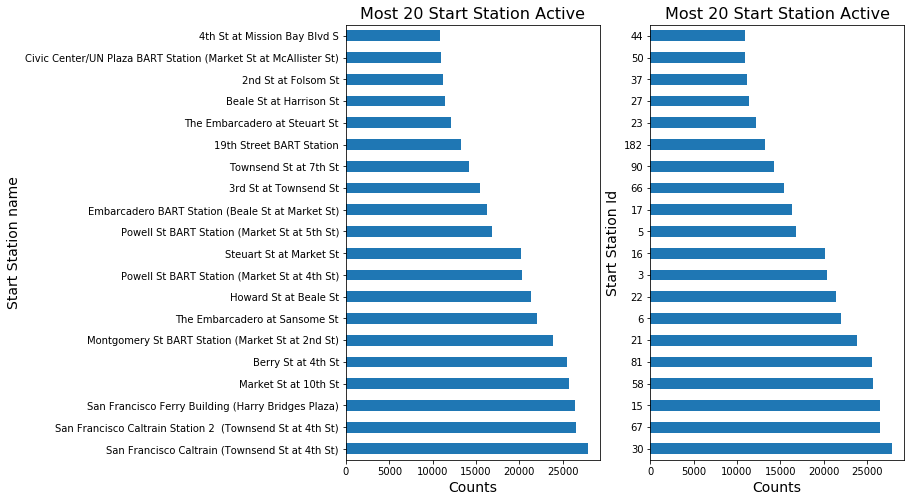

```python
# the most active start_station(by Id and Name)

plt.figure(figsize=[10,8])

plt.subplot(1,2,1)
gobike_copy['start_station_name'].value_counts()[:20].plot(kind='barh')
plt.title('Most 20 Start Station Active', fontsize=16)
plt.xlabel('Counts', fontsize=14)
plt.ylabel('Start Station name', fontsize=14);

plt.subplot(1,2,2)
gobike_copy['start_station_id'].value_counts()[:20].plot(kind='barh')
plt.title('Most 20 Start Station Active', fontsize=16)
plt.xlabel('Counts', fontsize=14)
plt.ylabel('Start Station Id', fontsize=14);
```

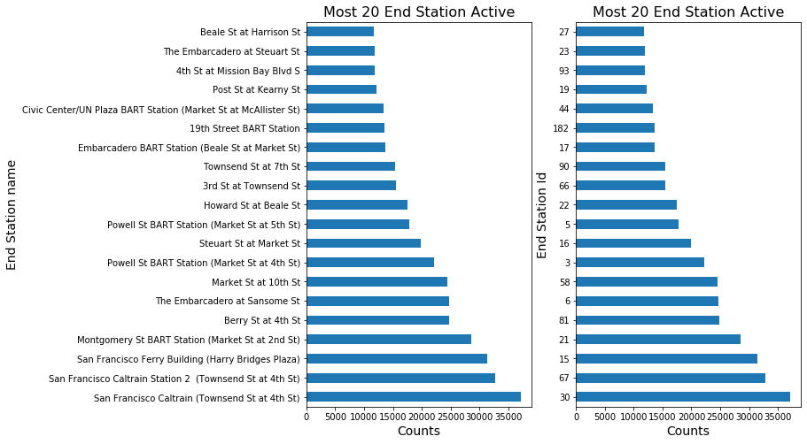

```python
# the most active end_station(by Id and Name)

plt.figure(figsize=[10,8])

plt.subplot(1,2,1)
gobike_copy['end_station_name'].value_counts()[:20].plot(kind='barh')
plt.title('Most 20 End Station Active', fontsize=16)
plt.xlabel('Counts', fontsize=14)
plt.ylabel('End Station name', fontsize=14);

plt.subplot(1,2,2)
gobike_copy['end_station_id'].value_counts()[:20].plot(kind='barh')
plt.title('Most 20 End Station Active', fontsize=16)
plt.xlabel('Counts', fontsize=14)
plt.ylabel('End Station Id', fontsize=14);
```

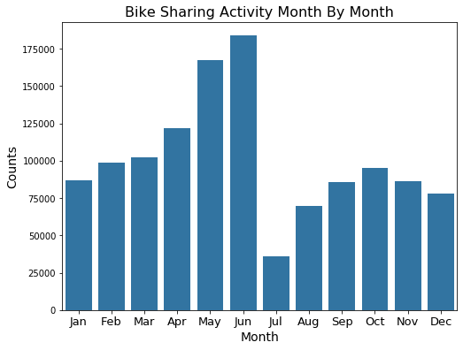

```python
# bike sharing activity monthly Disribution
plt.figure(figsize=[8,6])
gen_order=['Jan', 'Feb', 'Mar', 'Apr', 'May', 'Jun', 'Jul', 'Aug', 'Sep', 'Oct', 'Nov', 'Dec']
base_color=sb.color_palette()[0]
sb.countplot(data=gobike_copy, x='month', color=base_color, order=gen_order)
plt.title('Bike Sharing Activity Month By Month', fontsize=16)
plt.xlabel('Month', fontsize=14)
plt.ylabel('Counts', fontsize=14)
plt.xticks(fontsize=13);
```

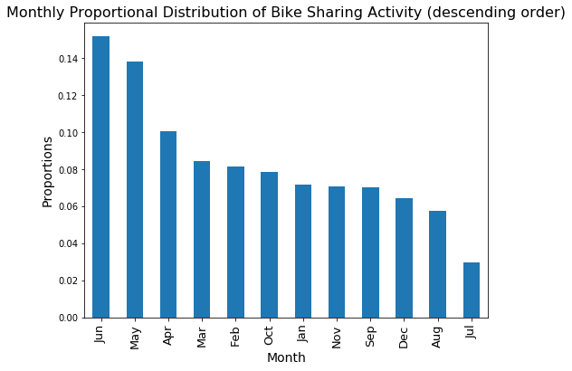

```python
# monthly bike sharing activity in descending order

plt.figure(figsize=[8,6])

base_color=sb.color_palette()[0]

n_points = gobike_copy.shape[0]
month_counts=gobike_copy['month'].value_counts()
month_prop=month_counts/n_points

month_prop.plot(kind='bar', color= base_color)
plt.title('Monthly Proportional Distribution of Bike Sharing Activity (descending order)', fontsize=16)
plt.xlabel('Month', fontsize=14)
plt.ylabel('Proportions', fontsize=14)
plt.xticks(fontsize=13);
```

## Distribution of member birth year

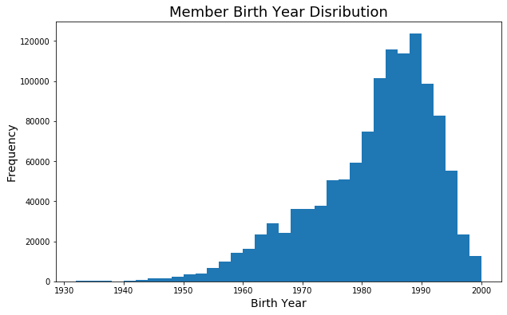

```python
plt.figure(figsize=[10,6])
gobike_copy.dropna(subset = ['member_birth_year'])
bin_edges = np.arange(1932, gobike_copy['member_birth_year'].max()+2, 2)
plt.hist(data = gobike_copy, x = 'member_birth_year', bins = bin_edges);
plt.title('Member Birth Year Disribution', fontsize=18)
plt.xlabel('Birth Year', fontsize=14)
plt.ylabel('Frequency', fontsize=14);
```

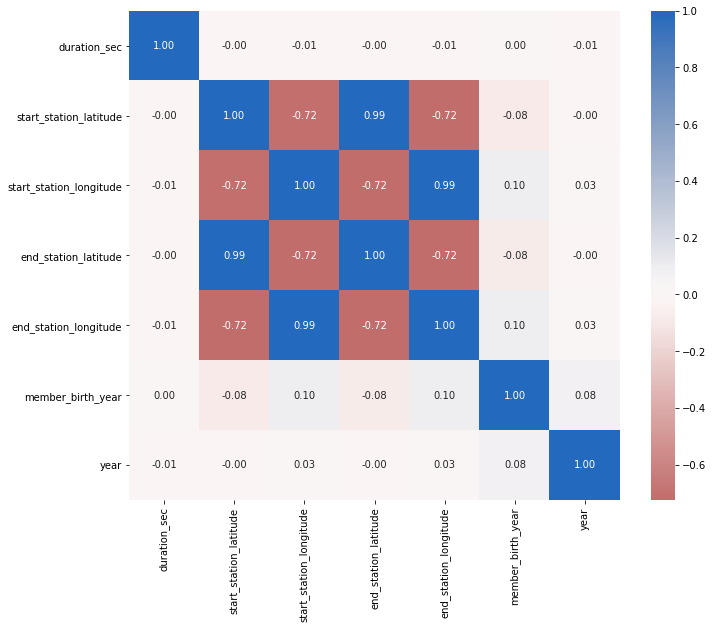

```python
# correlation coefficient strengths
plt.figure(figsize=(11,9))
sb.heatmap(gobike_subset.corr(), annot = True, fmt = '.2f', cmap = 'vlag_r', center = 0);
```

## Explanatory Visualizations

#### Now it is time to answer our posed questions and summarize the main findings:

### 1. When are the most numbers of trips taken in terms of:

### - period of day (morning, afternoon, evening and night)

### - weekdays (monday to sunday)

### - month of year (january till december)

#### starting with the first term (period of day): most trips are taken at the afternoon and morning times, the percentage of trips that are taken at afternoon time is about 43%, we may give the following percentage for each period of day:

#### - afternoon time: about: 43%

#### - morning time: about : 42%

#### - evening time: about : 14%

#### - night time: about : 1%

#### in the other hand the most trips are taken at weekdays are in Tuesday, Wednesday and Thursday (about 17.5% plus / minus, the peak value is on Tuesdays) then it descends gradually till it reachs to the undermost values (about 8.5% and 7.5%) on Saturdays and Sundays respectively (or on weekends)

#### in term of month of years: the maximum numbers of trips are taken in June month with about 15.2% then May with about 14% of the total trips. the least number of trips are taken in July with only about 3%.